# Chapter 10: The Priorities and Prioritization Tables

Below, we generate an object called **equations** that is formatted correctly for `simGlm()`. The list should contain a number of named elements equal to the number of target species, where the name of each element will be the model name (e.g., ‘btgn_vocals’). The ‘names’ list element contains a character vector of the temporal covariates in the model for that species; each covariate (with the exception of ‘intercept’) must match the name of a column available in the **temporal.data** object (case sensitive, pay attention to camelCase column conventions here). If desired, polynomial terms may be added to covariate names by including ‘.N’ next to the covariate (e.g. ‘distRise.2’ or ‘temperature.3’ to denote distRise^2 or temperature^3 in the below example). Polynomial terms are automatically parsed and applied within `simGlm()` via the ‘.’ character. Lastly, the ‘coefficients’ list element contains a numeric vector of the coefficient values we want to use in our model. For example, in the ‘btgn_vocals’ model below, the ‘intercept’ coefficient is -0.3, the ‘dayOfYear’ coefficient is -0.002, and so on. Importantly, the coefficients are on the logit (log odds) scale to ensure that the final probability is constrained between 0 and 1. Take care to ensure that all covariate names match up correctly in order with the coefficient values you want to use.

```r
# Example list of model equations for vocalization for each of four species
equations <- list(
  btgn_vocals = list(
    names = c('intercept', 'dayOfYear', 'daySin',
              'hourCos12', 'distRise.2','temperature',
              'temperature.3', 'windSpeed'),
    coefficients = c(-0.3, -0.002, 1,
                     -0.5, -0.000007, 0.009,
                     -0.000001, -0.35)
  ),
  copo_vocals = list(
    names = c('intercept', 'dayOfYear', 'dayCos',
              'daySin', 'hourCos24', 'hourCos12',
              'distRise', 'distSet', 'windSpeed',
              'moonCos'),
    coefficients = c(-2, -0.003, 0.5,
                     0.6, 1, -0.5,
                     -0.0005, -0.0005, -0.1,
                     -0.2)
  ),
  leni_vocals = list(
    names = c('intercept', 'dayOfYear', 'dayCos',
              'daySin', 'hourCos24', 'hourCos12',
              'distRise', 'distSet', 'windSpeed',
              'moonCos'),
    coefficients = c(-3, -0.006, 0.4,
                     0.7, 1, -0.5,
                     -0.0005, -0.0005, -0.25,
                     -0.3)
  ),
  verd_vocals = list(
    names = c('intercept', 'dayOfYear', 'daySin',
              'hourCos12', 'distRise.2','temperature',
              'temperature.3', 'windSpeed'),
    coefficients = c(-0.5, -0.004, 1,
                     -1.5, -0.000007, 0.009,
                     -0.000001, -0.25)
  )
)
```

Once the **equations** object is correctly formatted, we are ready to generate our models with `simGlm()`. If we want to use all data stored in the **temporals** database table to create the model, we feed our **db.path** object to the ‘db.path’ argument, and our **equations** object to the ‘equation’ argument (which is a list of four, so four models will be created). In the ‘model.type’ argument, we specify that we are creating actitivity models. R will recycle the **model.type** and **model.family** values for all four models. In the ‘model.family’ argument, we specify ‘binomial’ (alternatively, we can specify ‘poisson’ here if that is the type of model we mean to create). Instead of using *all* data in the temporals database, we feed our **temporal.data** object to the ‘data’ argument and leave the ‘db.path’ argument blank.

```r
# Create vocalization models:
models <- simGlm(equation = equations,
                 model.type = 'activity',
                 model.family = 'binomial',
                 data = temporal.data)
```

```
## Working on model 1 (btgn_vocals)...
```

```
## Finished model 1. Model btgn_vocals is active 12.7 % of the time.
```

```
## Working on model 2 (copo_vocals)...
```

```
## Finished model 2. Model copo_vocals is active 9.4 % of the time.
```

```
## Working on model 3 (leni_vocals)...
```

```
## Finished model 3. Model leni_vocals is active 1.6 % of the time.
```

```
## Working on model 4 (verd_vocals)...
```

```
## Finished model 4. Model verd_vocals is active 16.6 % of the time.
```

Each of these models is stored in a list (in this case a list of four, one for each species). The class of each model is **glm** (generalized linear model) and **lm** (linear model) generated from R’s base package, and each object contains a bevy of information about the model fitting process.

```r
# Look at the class of each model
lapply(X = models, FUN = class)
```

```
## $btgn_vocals
## [1] "glm" "lm"
##
## $copo_vocals
## [1] "glm" "lm"
##
## $leni_vocals
## [1] "glm" "lm"
##
## $verd_vocals
## [1] "glm" "lm"
```

We encourage readers to use the `str()` function to look more deeply at each model’s structure and to view the helpfiles for `lm()` and `glm()` for details about model output.

The plot below gives the reader some sense of what the coefficients mean. Each of the four species is plotted in five panels, with the probability of vocalization per unit time on the y-axis. The x-axes vary across the five panels, and demonstrate the influence of several different covariates on vocalization probability by species.

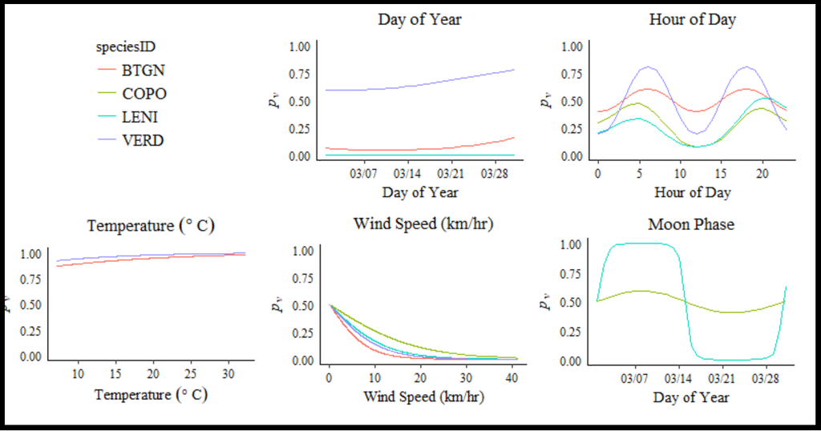

> *Figure 10.3. Plots showing how probability of vocalization varies as a function of covariates for four species.*

Such activity models are required for **AMMonitor’s** adaptive sampling algorithm in `scheduleOptim()` (described below). The models provide predictions of activity given tomorrow’s temporal conditions, and thus enable **AMMonitor** to create an optimized sampling scheme for future monitoring at each monitoring location. For example, if tomorrow’s forecast calls for 20 km/hr winds at 6am, we would expect that vocalization probability is lowest for ‘BTGN’ and highest for ‘COPO’ during that time (assuming both species are present at a site). If their *pCurrent* and *weight* values were equal, the optimization algorithm would target ‘COPO’ monitoring under these conditions because ‘BTGN’ will be less vocally available.

In the spirit of adaptive management, each model can be updated and improved through time as new data are collected. Additionally, each model will be repeatedly used by the optimization algorithm. As such, we store the models in the **activity** model library for easy retrieval and use.

```r
# Convert each model in the list to an amModel object
models <- lapply(models, FUN = amModel)

# Look at the structure of this object
# Note it is a list of amModel objects
str(models, max.level = 1)
```

```
## List of 4
##  $ btgn_vocals:Formal class 'amModel' [package "AMModels"] with 2 slots
##  $ copo_vocals:Formal class 'amModel' [package "AMModels"] with 2 slots
##  $ leni_vocals:Formal class 'amModel' [package "AMModels"] with 2 slots
##  $ verd_vocals:Formal class 'amModel' [package "AMModels"] with 2 slots
```

Notice that the **models** object is a list of four **amModel** objects, each which contains two slots. The first slot stores the model itself (the object of class “glm”). The second slot stores metadata about the model. We add these models to our activity model library:

```r
# Insert the models to the amModelLib as a named list
activity <- AMModels::insertAMModelLib(models = models, amml = activity)

# View a summary of the library
activity
```

```
##
## Description:
## [1] This library stores models that predict species activity patterns.
##
## Info:
##   PI
##    [1] Bilbo Baggins
##   Organization
##    [1] Middle Earth Conservancy
##
## Models:
##          name   class package
## 1 btgn_vocals glm, lm      NA
## 2 copo_vocals glm, lm      NA
## 3 leni_vocals glm, lm      NA
## 4 verd_vocals glm, lm      NA
##
## Data:
##
##  --- There are no datasets ---
```

The four models have been added to the libary. **For these models to be used by other AMMonitor functions, users must also add metadata for each model.** Below, we will create a named list of metadata elements (in key-value fashion), and specify that these are activity models of class ‘glm’ created with the **AMMonitor** function `simGlm()`. At minimum, the model metadata list should contain the ‘type’ (model type), ‘class’, ‘speciesID’ (if any), ‘packageName’, and ‘functionName’ (if any). Importantly, if the model is linked to a particular objective in the **objectives** table, a metadata element called ‘objectiveID’ may be entered. Other desired metadata information can be added at the user’s discretion. **For the examples in this vignette, the speciesID metadata is critical for the `scheduleOptim()` function, which will check that speciesIDs match those available in the species table.**

```r
# create a named list of of metadata that can be added to all objects
model.meta <- list(type = 'activity model',
                   class = 'glm',
                   model.family = 'binomial',
                   speciesID = 'NA',
                   objectiveID = 'NA',
                   package = 'AMMonitor',
                   functionName = 'simGlm')

# Add speciesID metadata to the btgn object
model.meta$speciesID = 'btgn'
AMModels::modelMeta(amml = activity, x = 'btgn_vocals') <- model.meta

# Add speciesID metadata to the verd object
model.meta$speciesID = 'verd'
AMModels::modelMeta(amml = activity, x = 'verd_vocals') <- model.meta

# Add speciesID metadata to the copo object
model.meta$speciesID = 'copo'
AMModels::modelMeta(amml = activity, x = 'copo_vocals') <- model.meta

# Add speciesID metadata to the leni object
model.meta$speciesID = 'leni'
AMModels::modelMeta(amml = activity, x = 'leni_vocals') <- model.meta
```

Now that we have added metadata for each **amModel** object, we can save the library back to our *ammls* directory for future use:

```r
# Save the library
saveRDS(activity, file = 'ammls/activity.RDS')
```

# Setting an optimized schedule with scheduleOptim()

After establishing monitoring priorities in the **priorities** table, initializing a new monitoring session with `priorityInit()`, and generating models with `simGlm()`, we are situated to conduct optimized monitoring using `scheduleOptim()`. The primary purpose of `scheduleOptim()` is to create an optimized schedule for future monitoring based on monitoring priorities, activity models, and temporal data that contain tomorrow’s forecast. The resulting schedule is added to the **schedules** table, where the schedule can be synced with each smartphone’s Google Calendar. **Note that `scheduleOptim()` currently only focuses on schedule optimization for recordings. Optimization for motion capture, photos, and playback will be incorporated in future versions of AMMonitor.**

Here, we demonstrate `scheduleOptim()` to set an acoustic monitoring schedule for the four target species across three sites. To begin, we view `scheduleOptim()`’s arguments:

```r
# Look at the arguments to scheduleOptim()
args(scheduleOptim)
```

```
## function (db.path, calendar.key = NULL, amml, choose.models,
##     temporals.key = NULL, optimization.approach = "simple", daily.site.constraint,
##     time.units, max.per.hour = NULL, db.insert = FALSE, google.push = FALSE)
## NULL
```

This function will create a schedule to be pushed to a smartphone’s Google Calendar and inserted to the **schedules** database table. The arguments *db.insert* and *google.push* offer the chance to test `scheduleOptim()` before implementing it. The other arguments include:

- ‘db.path’ - The filepath to the **AMMonitor** database.
- ‘calendar.key’ - The calendar key for the monitoring program’s primary Google account. The **accounts** table should have an entry for this key, and the key itself should be stored in the **settings** directory within the **AMMonitor** main directory (see Chapter 7: The Accounts, Equipment, Deployment, and Logs Tables, and Chapter 9: The Schedule Table). The ‘calendar.key’ argument can be set to NULL when we are merely testing the function.
- ‘amml’ - The name of the AMModels library storing models that predict activity based on forecasted weather conditions.
- ‘choose.models’ - A character vector of the model names stored within the AMModels library. In practice, we may have many models stored in our AMModel library, and this argument forces us to specify which models we actually want to use. Model names do not need to be given in alphabetical order.
- ‘time.units’ - Tells `scheduleOptim()` the time scale for how we modeled our activity. If we modeled binomial vocalization probabilities or Poisson rates by the minute, then we input ‘by.minute’. If we modeled activity on an hourly basis, we input ‘by.hour’.
- ‘temporals.key’ - The Dark Sky API key used to retrieve forecast conditions at each monitoring location. The **accounts** table should have an entry for this key, and the key itself should be stored in the **settings** directory within the **AMMonitor** main directory (see Chapter 8: The Temporals Table). In an active, real-time monitoring program, one will always need to include the ‘temporals.key’. However, users can leave ‘temporals.key’ as the default NULL if they wish to conduct academic exercises or activity simulations using historical weather data [2].
- ‘optimization.approach’ - The approach to be used to set the optimized schedule. This argument requires a single character element of one of two options: ‘simple’ (default) or ‘max.per.hour’.
- ‘daily.site.constraint’ - The number of recordings to be collected per site per day.
- ‘max.per.hour’ - The maximum number of recordings to schedule per hour.

Note that there are two alternative optimization approaches (‘simple’ or ‘max.per.hour’). Regardless of the approach, recording events are 1 minute in duration, and require at least one minute of non-recording buffer time between events. This gives the smartphone time to process each audio file before embarking on a new recording. Additionally, limiting the duration of events to 1 minute ensures that the audio file can be reliably dispatched over the cellular network. Note that although the schedule is set to the minute, our temporal data from Dark Sky is only available to the hour. Thus, the optimization algorithm will rank each hour from best to worst (n = 24) for each site in terms of expected monitoring proficiency, given the 24 hour temporal forecast. The ‘daily.site.constraint’ argument should contain the total recording time, in minutes, that should be taken at each active monitoring location every day; a value of 5 indicates that five minutes of recordings will be taken at all three of our actively monitored locations.

Under the ‘simple’ optimization approach, the ‘daily.site.constraint’ argument should contain the number of 1-minute recording samples available to be taken each day at each site. In cases where ‘daily.site.constraint’ <= 30, all events are allotted into the highest scoring hour at evenly spaced intervals throughout the hour. If ‘daily.site.constraint’ > 30, remaining samples are allotted in the same way into the second highest scoring hour, and so on.

Some users may chafe at the idea of concentrating all sampling power into a single hour if they have fewer than 30 samples per day, and may choose to set the ‘optimization.approach’ argument to ‘max.per.hour’ instead. In this approach, users can set a maximum cap on the number of samples distributed into any single hour by providing a value for the ‘max.per.hour’ argument, which indicates the maximum number of samples allotted to any single hour. Note that when activity models are well-informed and weather predictions are reliable, the ‘max.per.hour’ method may be slightly inferior to the ‘simple’ method [2]. However, if weather predictions are unreliable and/or activity models are not well-informed, users may prefer to hedge their bets by distributing samples across more hours.

Below, we provide an example of how to create an optimized recording schedule for the four sample species across three locations. Here, we will use the ‘simple’ optimization approach, and limit the number of recordings per site per day to 5 in the ‘daily.site.constraint’ argument. The arguments ‘db.insert’ and ‘google.push’ are set to FALSE to demonstrate the function.

```r
#----------------------------------------------------------------
# Optimize the schedule for tomorrow  and return the results as a
# list of two data.tables: prioritization, and schedule.
# Set db.insert and google.push to FALSE to ensure results are not
# added to the database. No calendar.key is required, but a temporals.key
# will be required to get a new forecast for tomorrow.
#----------------------------------------------------------------

test_optim <- scheduleOptim(db.path = db.path,
                            amml = activity,
                            choose.models = c('copo_vocals', 'leni_vocals',
                                              'btgn_vocals', 'verd_vocals'),
                            temporals.key = 'settings/dark-sky-key.RDS',
                            calendar.key = NULL,
                            optimization.approach = 'simple',
                            daily.site.constraint = 5,
                            time.units = 'by.hour',
                            max.per.hour = NULL,
                            db.insert = FALSE,
                            google.push = FALSE)
```

```
## Powered by Dark Sky: visit https://darksky.net/poweredby/ for details
```

```
## Gathering temporal data for 1 out of 3 cases.
```

```
## Gathering temporal data for 2 out of 3 cases.
```

```
## Gathering temporal data for 3 out of 3 cases.
```

```
## Predicting activity for species 1: btgn
```

```
## Predicting activity for species 2: copo
```

```
## Predicting activity for species 3: leni
```

```
## Predicting activity for species 4: verd
```

As shown, `scheduleOptim()` yields progress messages about the gathering of forecast data and model status for our focal species.

Note that the **test_optim** object returned by `scheduleOptim()` is a list of two data.tables: the **prioritization** table and the **schedule** table.

```r
# Confirm that the output is a list of 2:
str(object = test_optim, max.level = 1)
```

```
## List of 2
##  $ prioritization:Classes 'data.table' and 'data.frame': 12 obs. of  7 variables:
##   ..- attr(*, ".internal.selfref")=<externalptr>
##  $ schedule      :Classes 'data.table' and 'data.frame': 15 obs. of  9 variables:
##   ..- attr(*, ".internal.selfref")=<externalptr>
```

First, we view the prioritization table:

```r
# Look at prioritization table output
test_optim['prioritization']
```

```
## $prioritization
##     locationID speciesID       date pMax     pCurrent weight init
##  1: location@1      btgn 2019-07-13 0.95 0.0005386006      1    0
##  2: location@1      copo 2019-07-13 0.95 1.0000000000      0    0
##  3: location@1      leni 2019-07-13 0.95 1.0000000000      0    0
##  4: location@1      verd 2019-07-13 0.95 1.0000000000      0    0
##  5: location@2      btgn 2019-07-13 0.95 0.0011690633      1    0
##  6: location@2      copo 2019-07-13 0.95 1.0000000000      0    0
##  7: location@2      leni 2019-07-13 0.95 1.0000000000      0    0
##  8: location@2      verd 2019-07-13 0.95 1.0000000000      0    0
##  9: location@3      btgn 2019-07-13 0.95 0.0005298281      1    0
## 10: location@3      copo 2019-07-13 0.95 1.0000000000      0    0
## 11: location@3      leni 2019-07-13 0.95 1.0000000000      0    0
## 12: location@3      verd 2019-07-13 0.95 1.0000000000      0    0
```

The prioritization table contains 12 rows; one row for each of the four target species at each of three active monitoring locations. Though the *locationID*, *speciesID*, and *pMax* columns should look the same as the first day, the *weight*, *pCurrent*, *date*, and *init* columns look different.

Firstly, the *date* should change, and *init* will now hold values of 0 because the optimization routine was not initialized on this day.

Secondly, the *weight* values should change as a function of *pCurrent*. Species whose probability of acoustic capture (*pCurrent*) went up dramatically may see their monitoring weights go down, while species whose *pCurrent* did not rise as rapidly may see their monitoring weights go up.

Next, we look at the schedule table:

```r
# Look at schedule table output
test_optim['schedule']
```

```
## $schedule
##       Subject Start Date Start Time   End Date End Time All Day Event    Description   Location Private
##  1: Recording 2019-07-13   06:00:00 2019-07-13 06:01:00         False Optim Calendar location@1   False
##  2: Recording 2019-07-13   06:12:00 2019-07-13 06:13:00         False Optim Calendar location@1   False
##  3: Recording 2019-07-13   06:24:00 2019-07-13 06:25:00         False Optim Calendar location@1   False
##  4: Recording 2019-07-13   06:36:00 2019-07-13 06:37:00         False Optim Calendar location@1   False
##  5: Recording 2019-07-13   06:48:00 2019-07-13 06:49:00         False Optim Calendar location@1   False
##  6: Recording 2019-07-13   05:00:00 2019-07-13 05:01:00         False Optim Calendar location@2   False
##  7: Recording 2019-07-13   05:12:00 2019-07-13 05:13:00         False Optim Calendar location@2   False
##  8: Recording 2019-07-13   05:24:00 2019-07-13 05:25:00         False Optim Calendar location@2   False
##  9: Recording 2019-07-13   05:36:00 2019-07-13 05:37:00         False Optim Calendar location@2   False
## 10: Recording 2019-07-13   05:48:00 2019-07-13 05:49:00         False Optim Calendar location@2   False
## 11: Recording 2019-07-13   06:00:00 2019-07-13 06:01:00         False Optim Calendar location@3   False
## 12: Recording 2019-07-13   06:12:00 2019-07-13 06:13:00         False Optim Calendar location@3   False
## 13: Recording 2019-07-13   06:24:00 2019-07-13 06:25:00         False Optim Calendar location@3   False
## 14: Recording 2019-07-13   06:36:00 2019-07-13 06:37:00         False Optim Calendar location@3   False
## 15: Recording 2019-07-13   06:48:00 2019-07-13 06:49:00         False Optim Calendar location@3   False
```

This is the schedule that can be pushed to Google Calendar, if desired. Notice that the schedule has a total of 15 rows; five for each of three active monitoring locations because ‘daily.site.constraint’ was set to 5. The 5 minutes of sampling for each site have been allotted in 1-minute increments to the highest scoring hour (the hour where we are likely to get the highest payoff in terms of acoustically capturing our target species). Notice that this highest scoring hour may be different for different sites, or may be the same, depending on the temporal data available and the date upon which you are running this demo.

If we are confident that we understand the test results and everything looks to be in order, we can set ‘db.insert’ and ‘google.push’ to TRUE, making sure to add a file path to our Google Calendar service token in the ‘calendar.key’ argument (the functionality of these arguments is the same as that in Chapter 9: The Schedule Table).

# Running a simulation experiment on historical temporal data

In advance of implementing a real-time optimized monitoring program integrated with daily forecast data, users may wish to test the concept out with a simulation of their system using real historical weather data. Historical data may be collected via `temporalsGet()` for all dates and locations of interest, and stored in the **temporals** table.

First, for the purposes of demonstration only, we carefully use `dbClearTables()` to clear the **prioritization** table and start over (this is a function that should only be used in the testing stages of setting up a monitoring database):

```r
dbClearTables(db.path = db.path, tables = c('schedule', 'prioritization'))
```

```
## Deleted all records from schedule table.
```

```
## Deleted all records from prioritization table.
```

Since we already have historical temporals data in the example database that ranges from 2016-03-01 to 2016-03-31, we can run a simulation experiment for the entire month of March 2016 to see how the optimized monitoring routine performs.

This time we will input ‘2016-03-01’ into the ‘init.date’ argument of `priorityInit()`:

```r
# Run the priorityInit function:
priorityInit(db.path = db.path, init.date = '2016-03-01')
```

```
## Finished initializing prioritization table.
```

To run `scheduleOptim()` as a simulation, we set ‘db.insert’ to TRUE to add data to the database. We set the argument ‘google.push’ to FALSE to avoid calls to Google Calendar (in the simulation setting, there is no need to push events to Google Calendar). This way, we can run a simulation, interact with the database, and observe results without having to worry about touching the Google Calendar API. To run a multi-day simulation, we can loop over `scheduleOptim()` for as many days as we like based on how much historical data we have available in the **temporals** table. Below, we suppress `scheduleOptim()`’s messages and instead use **i** as a counter to track progress through a 30 day experiment, where day 1 serves as the first day of monitoring (*init* = 1 and *pCurrent* = 0 for all species and sites).

```r
# Run the simulation
for (i in 1:30) {
  suppressMessages(scheduleOptim(db.path = db.path,
                                 amml = activity,
                                 choose.models = c('copo_vocals', 'leni_vocals',
                                                   'btgn_vocals', 'verd_vocals'),
                                 temporals.key = NULL,
                                 calendar.key = NULL,
                                 optimization.approach = 'simple',
                                 daily.site.constraint = 5,
                                 time.units = 'by.hour',
                                 max.per.hour = NULL,
                                 db.insert = TRUE,
                                 google.push = FALSE))
  cat(i, ' ')
}
```

```
## 1  2  3  4  5  6  7  8  9  10  11  12  13  14  15  16  17  18  19  20  21  22  23  24  25  26  27  28  29  30
```

We can use the `qryPrioritization()` function to observe *pCurrent* for all target species at all actively monitored locations when the simulation is complete:

```r
# Query the prioritization table
qryPrioritization(conn = conx)
```

```
##    locationID speciesID weight  pCurrent pMax       date init
## 1  location@1      btgn      0 1.0000000 0.95 2016-03-31    0
## 2  location@1      copo      0 1.0000000 0.95 2016-03-31    0
## 3  location@1      leni      0 0.9980467 0.95 2016-03-31    0
## 4  location@1      verd      0 1.0000000 0.95 2016-03-31    0
## 5  location@2      btgn      0 1.0000000 0.95 2016-03-31    0
## 6  location@2      copo      0 1.0000000 0.95 2016-03-31    0
## 7  location@2      leni      0 0.9978393 0.95 2016-03-31    0
## 8  location@2      verd      0 1.0000000 0.95 2016-03-31    0
## 9  location@3      btgn      0 1.0000000 0.95 2016-03-31    0
## 10 location@3      copo      0 1.0000000 0.95 2016-03-31    0
## 11 location@3      leni      0 0.9980499 0.95 2016-03-31    0
## 12 location@3      verd      0 1.0000000 0.95 2016-03-31    0
```

By default, `qryPrioritization()` will return records associated with the most recent day in monitoring period (in this case, 2016-03-31). When a species’ *pCurrent* equals or exceeds *pMax*, that species’ weight becomes 0, allowing monitoring resources to focus on species that have not yet attained *pMax*.

As usual, when finished working with an **AMMonitor** database, we use the `dbDisconnect()` function:

```r
# Disconnect from the database
dbDisconnect(conx)
```

# Running scheduleOptim() in a script

`scheduleOptim()` may be employed on daily basis to set an optimized schedule pushed to each smartphone’s Google calendar. To facilitate the process of manually running this function each day, a monitoring team may opt to automatically run `scheduleOptim()` daily via an “script” which is sourced each morning by a member of the monitoring team. Scripts are described in detail in Chapter 19.

# The Priorities Table in Access

Because monitoring priorities are established at the discretion of the monitoring team, they can be found under the “Objectives” primary tab of the Access Navigation Form.

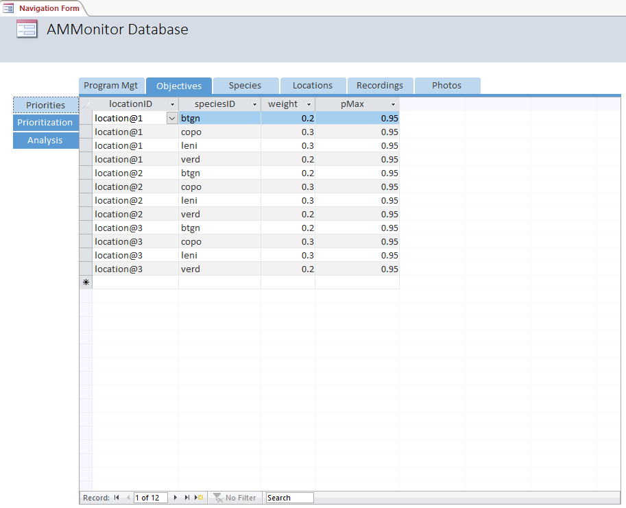

> *Figure 10.4. Priorities are set by the monitoring team. The priorities tab is nested under the main tab, “Objectives”.*

Here, we see the built-in data that comes with our Chap10.SQLite sample database, which consists of monitoring weights for four species across three sites. Recall that for any given site, the sum of the weights must equal 1. Also recall that *pMax* provides a stopping rule that dictates when a species can be dropped from monitoring consideration at a site.

# The Prioritization Table in Access

The prioritization table is also located under the “Objectives tab”. The data are colored red to remind us that they are automatically filled in by **AMMonitor** functions and are not to be edited by hand.

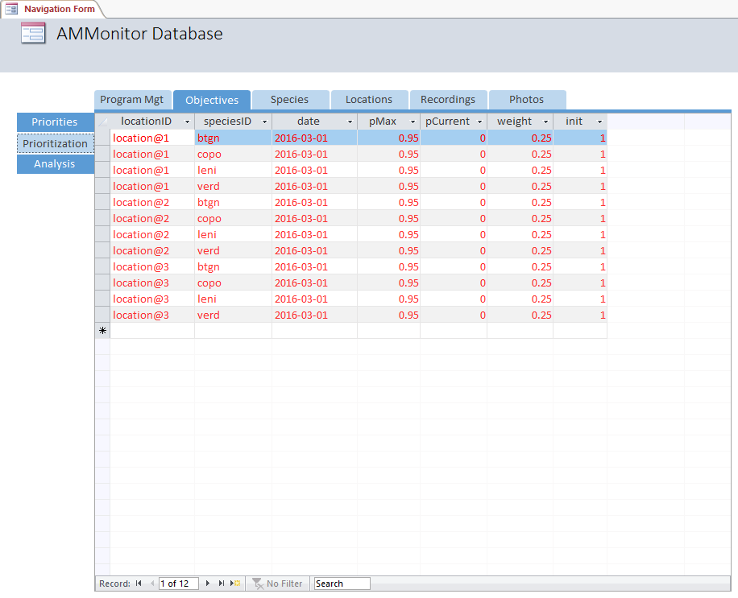

> *Figure 10.5. The prioritization table is located under the Objectives main tab, and provides the current state of monitoring priority for each species at each location. This table is populated by R and should not be edited by hand.*

The search tool at the bottom of this form can be used to quickly locate current priorities for a given species at a given location.

# Chapter Summary

This chapter covered the **priorities** and **prioritization** tables, which are used to track the capture probabilities of multiple target monitoring species at active smartphone monitoring locations. `prioritySet()` is a convenience function that can be used to set equal monitoring priority weights for species at monitoring locations. `priorityInit()` establishes monitoring priorities at the beginning of a temporally adaptive monitoring period based on information contained in the **priorities** table. `simGlm()` may be used to generate the activity models required by `scheduleOptim()`, which sets a schedule optimized according to temporal forecast data, monitoring priorities, and activity models. In addition to being implemented in a live monitoring context, `scheduleOptim()` may be used with historical data to run simulations. More information about the optimization scheme employed in **AMMonitor** can be found in [2].

# Chapter References

2. Balantic CM, Donovan TM. Temporally adaptive acoustic sampling to maximize detection across a suite of focal wildlife species. Ecology and Evolution.